# Lecture 8: Regression discontinuity

Jack Blundell

PUBLPOL 330D Applied Econometrics for Public Policy, Winter 2020

- My email: jackblundell@stanford.edu
- My office hours: 8.30 - 10.30am every Thursday at Econ 350 (Landau building)
- Section (further office hours): 2.30 - 3.20pm every Friday (Bass B312)

## 0. Set up simulated dataset

Just for the purpose of this tutorial, I first build a simulated dataset

```stata
. clear

. set obs 10000
number of observations (_N) was 0, now 10,000

. set seed 123

. gen test_score = runiform(0,100)

. gen p_degree = 0 + test_score/400

. replace p_degree = 0.5 + test_score/400 if test_score >= 70
(3,013 real changes made)

. gen degree_rnum = runiform(0,1)

. gen degree = 0

. replace degree = 1 if degree_rnum < p_degree
(2,775 real changes made)
```

```stata
. gen earnings = rnormal(30,1)

. replace earnings = earnings + 3 if degree == 1
(2,775 real changes made)
```

## 1. (Fuzzy) regression discontinuity

We would like to assess the earnings returns to getting a degree.

The setting is that there is a standardized test which determines entry into college.

There is a threshold of 70, above which everone gets an offer.

For those who get a score below 70, there are still routes into college but it is significantly less likely.

This is a textbook fuzzy regression discontinuity setting.

We will use the command `rd`, which you will have to install using `ssc install`.

Lets first plot the probability of obtaining a degree over test score.

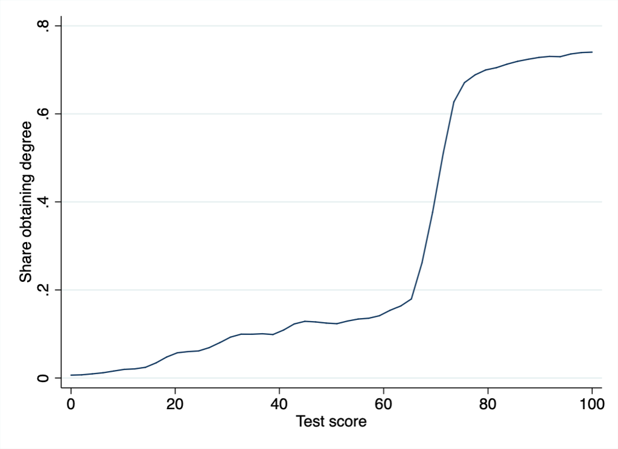

Test scores and degree probability

```stata
. twoway lpoly degree test_score, graphregion(color(white)) ///
> ytitle("Share obtaining degree") ///
> xtitle("Test score")

. graph export "poly_fit_degree.png", replace
(file poly_fit_degree.png written in PNG format)
```

Next I use the `rd` command to estimate the boost in the probability of obtaining a degree around the threshold of 70.

```stata
. rd degree test_score, z0(70)
Two variables specified; treatment is
assumed to jump from zero to one at Z=70.

 Assignment variable Z is test_score
 Treatment variable X_T unspecified
 Outcome variable y is degree

Estimating for bandwidth 2.81444015661577
Estimating for bandwidth 1.407220078307885
Estimating for bandwidth 5.62888031323154
─────────────┬────────────────────────────────────────────────────────────────
      degree │      Coef.   Std. Err.      z    P>|z|     [95% Conf. Interval]
─────────────┼────────────────────────────────────────────────────────────────
       lwald │   .5894928   .0740284     7.96   0.000     .4443997    .7345859
     lwald50 │   .5775503   .1040789     5.55   0.000     .3735594    .7815412
    lwald200 │   .5293372   .0530041     9.99   0.000      .425451    .6332233
─────────────┴────────────────────────────────────────────────────────────────
```

We estimate that reaching the threshold increases the probability by 59 percentage points. The three different results correspond to different bandwidths. I choose the first one somewhat arbitrarily.

We can also plot earnings by test score:

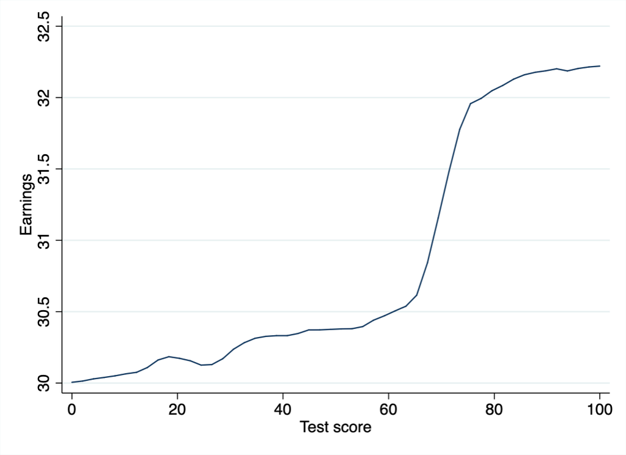

Test scores and earnings

```stata
. twoway lpoly earnings test_score, graphregion(color(white)) ///
> ytitle("Earnings") ///
> xtitle("Test score")

. graph export "poly_fit_earnings.png", replace
(file poly_fit_earnings.png written in PNG format)
```

Next I use the `rd` command to estimate the boost in earnings around the threshold of 70.

```stata
. rd earnings test_score, z0(70)
Two variables specified; treatment is
assumed to jump from zero to one at Z=70.

 Assignment variable Z is test_score
 Treatment variable X_T unspecified
 Outcome variable y is earnings

Estimating for bandwidth 3.710892471962227
Estimating for bandwidth 1.855446235981113
Estimating for bandwidth 7.421784943924454
─────────────┬────────────────────────────────────────────────────────────────
    earnings │      Coef.   Std. Err.      z    P>|z|     [95% Conf. Interval]
─────────────┼────────────────────────────────────────────────────────────────
       lwald │   1.845421   .2346194     7.87   0.000     1.385575    2.305266
     lwald50 │    1.81642    .320624     5.67   0.000     1.188009    2.444832
    lwald200 │   1.630205   .1685503     9.67   0.000     1.299852    1.960557
─────────────┴────────────────────────────────────────────────────────────────
```

Now I run the full regression discontinuity.

This means that we use the test score threshold to get variation in degrees, and then use that variation to find out the earnings return to a degree:

```stata
. rd earnings degree test_score, z0(70)
Three variables specified; jump in treatment
at Z=70 will be estimated. Local Wald Estimate
is the ratio of jump in outcome to jump in treatment.

 Assignment variable Z is test_score
 Treatment variable X_T is degree
 Outcome variable y is earnings

Estimating for bandwidth 3.710892471962227
Estimating for bandwidth 1.855446235981113
Estimating for bandwidth 7.421784943924454
─────────────┬────────────────────────────────────────────────────────────────
    earnings │      Coef.   Std. Err.      z    P>|z|     [95% Conf. Interval]
─────────────┼────────────────────────────────────────────────────────────────
       numer │   1.845421   .2341478     7.88   0.000       1.3865    2.304342
       denom │   .5753128   .0652194     8.82   0.000      .447485    .7031405
       lwald │   3.207683   .2810784    11.41   0.000     2.656779    3.758586
     numer50 │    1.81642   .3194164     5.69   0.000     1.190376    2.442465
     denom50 │   .5642868   .0892516     6.32   0.000     .3893568    .7392167
     lwald50 │   3.218967   .4324253     7.44   0.000     2.371429    4.066505
    numer200 │   1.630205    .168384     9.68   0.000     1.300178    1.960231
    denom200 │   .5167046   .0468351    11.03   0.000     .4249096    .6084997
    lwald200 │   3.155003    .212511    14.85   0.000     2.738489    3.571517
─────────────┴────────────────────────────────────────────────────────────────
```

We estimate that getting a degree increases earnings by 3.2, again arbitrarily choosing the first bandwidth.

The ‘numer’ gives the effect on earnings. The ‘denom’ gives the effect on degrees. The ‘wald’ gives the implied effect of degrees on earnings.

## 2. Practical concerns

### 2.1 Plotting

You can also plot using the `rdplot` command (from `ssc install rdrobust`), which will give a better idea for what exactly RD is doing:

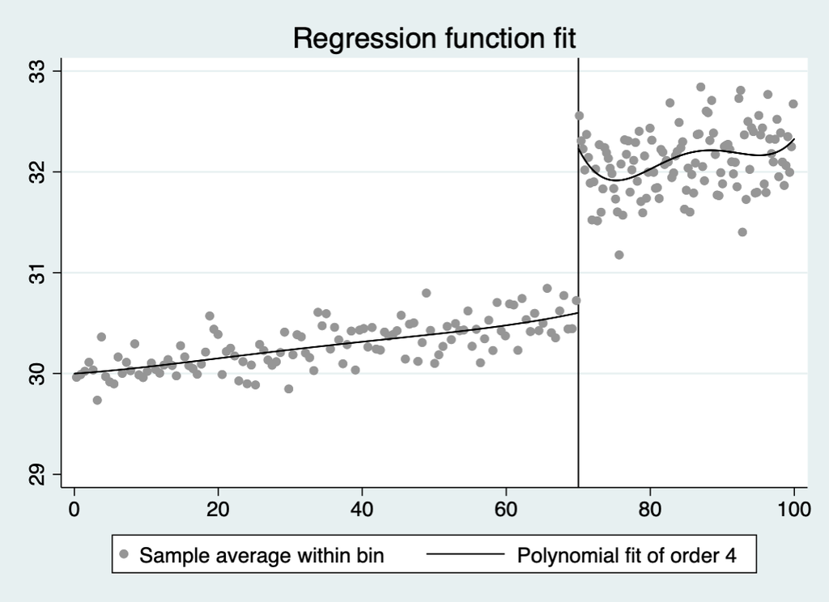

Test scores and earnings

```stata
. rdplot earnings test_score, c(70)

RD Plot with evenly spaced mimicking variance number of bins using spacings estimators.

        Cutoff c = 70 │ Left of c  Right of c        Number of obs  =      10000
──────────────────────┼──────────────────────        Kernel         =    Uniform
        Number of obs │      6987        3013
   Eff. Number of obs │      6987        3013
  Order poly. fit (p) │         4           4
     BW poly. fit (h) │    69.997      29.980
 Number of bins scale │     1.000       1.000

Outcome: earnings. Running variable: test_score.
──────────────────────┬──────────────────────
                      │ Left of c  Right of c
──────────────────────┼──────────────────────
        Bins selected │       121         119
   Average bin length │     0.578       0.252
    Median bin length │     0.578       0.252
──────────────────────┼──────────────────────
    IMSE-optimal bins │         7           7
  Mimicking Var. bins │       121         119
──────────────────────┼──────────────────────
Rel. to IMSE-optimal: │
        Implied scale │    17.286      17.000
    WIMSE var. weight │     0.000       0.000
    WIMSE bias weight │     1.000       1.000
──────────────────────┴──────────────────────


. graph export "rdplot.png", replace
(file rdplot.png written in PNG format)
```

### 2.2 Checking other covariates

A common thing to do in regression discontinuity which will add credibility to your estimate is to show that there is no change in other characteristics around the threshold. You can do this by replace the outcome variable in the `rdr` command with an alternative characteristic that you’d like to test for.

## 3. Problem set specific help

- The dataset provided is on third graders. You can find the relevant discontinuity (cutoff) by checking Section III of the paper.
- You may also want to set the cutoff at 0.01 below the actual cutoff infered from the paper, again because the data is very discrete